# 2023年度労務管理論

2023-04-25 09:14:34

## 科学的管理法の系譜と応用例

## 欧州からやってきた規格化という思想

- 欧州発兵器部品互換性確立構想
  - 破損した兵器を後送不要にする規格化は、火力を維持させる。
  - 手作り火器では後送必要。規格化火器製造業者による抵抗で潰える。
- トマス・ジェファーソン（米国第3代大統領）が発想を米国へ持ち帰った
- 橋本毅彦(2013)『「ものづくり」の科学史：世界を変えた「標準革命』講談社。

## ウィリアム・セラーズによる規格制定

- ねじ規格を提唱する
  - 社内規格から国内標準へ
  - セラーズは各社が内々にもっていた規格の平均を標準にしようと提案
  - 現代に残るインチねじ：外径単位がインチで頂角が55度（ウィット）ないし60度（ユニファイ）。
  - 日本はメートルねじ
- セラーズはベスレヘム・スチールミッドベール工場にてTaylorを雇ってくれた

## ISOねじ規格：ねじは人類による最重要発明。ねじの規格も同様。

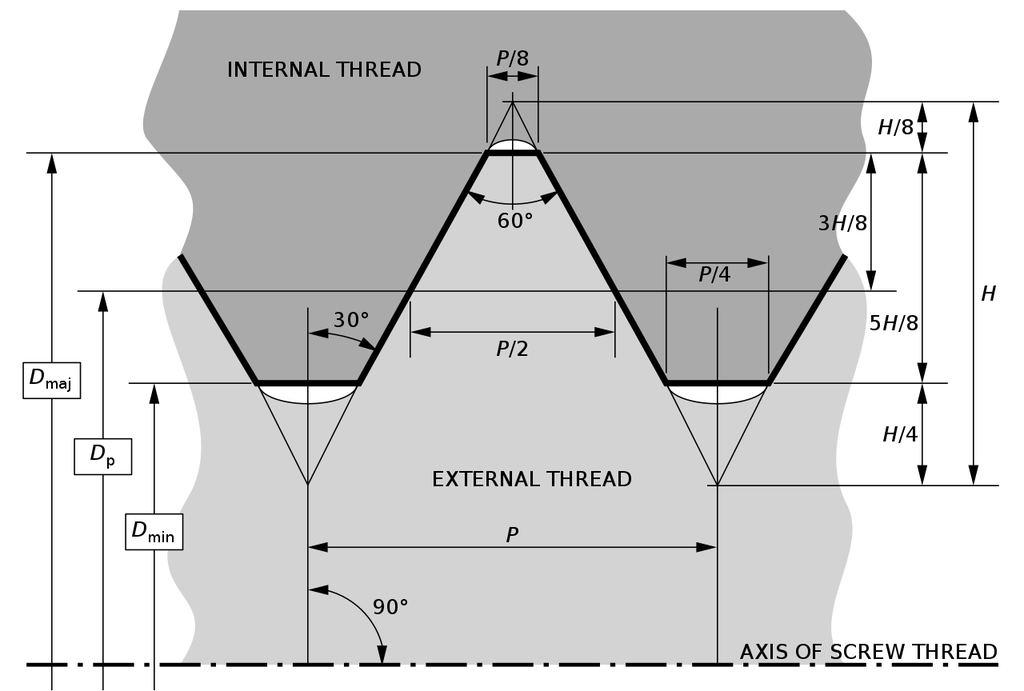

## Taylorの後継者たち

- ヘンリー・ガント
  - Taylorの弟子。ガントチャートを発案。
  - 今日、線表（せんぴょう）として活用される。
- ギルブレス夫妻
  - Taylorの後継者。ミクロモーションスタディを発案

## フォードによる4S

### 同期化Syncronizationを加え、手待ち時間短縮を企図

- 科学的管理法に同期化を加える
- 例）3工程の場合：工程Bにおいて仕掛品滞留発生、工程Cにおいて手待ち発生。

[interactive chart not shown]

## 労働者が考えることはなにもなくなった

- 単調労働repetitious workと呼ばれる極端に単純な労働になる
- 映画”*Modern times*”にくわしい
- 仕事がつまらないという不満を表明する方法がない
  - 労働組合は産別が主で、かつ使用者から弾圧されていた
  - 退職するしかない

## 好況は行動を変える

- フォードの時代は「金ぴか時代」と称される好況
  - 職業選択する余地がある
  - 単調労働を許容しなくなる
  - 移民はもう制限された
- 生存以上を職業に求める
  - 社会的地位・尊敬などは以前から存在はした
  - 科学的管理法が適用される職場において上記は想定外

## 退職率上昇

- 14,000人を充足するために、52,000人を採用しつづける
  - 能率が下がり、結果として労働生産性が下がる
  - 採用に要する費用も馬鹿にならない
- 高賃金政策を実施したが効なし

## 課題

\[ \underbrace{Labour\ productivity}_{労働生産性} = \frac{\overbrace {Production\ volume}^{生産量}}{\underbrace {Input\ Labour\ force}_{投入労働力量}} \times \underbrace{Unit\ price}_{製造単価} \]

## 人間関係論と行動科学

## 動機づけMotivation

- 人間自販機モデル：機械対自販機…
  - 誘引：労働意欲を高めるなにか
  - 労働意欲：働きたくなる心情
  - 労働生産性：前期参照。労働意欲が高くなると高くなるらしい
- 金銭以外に誘引はありやなしや

## ホーソン実験概要

- 1924-1932年にウェスタン・エレクトリック社にて実施
- 作業条件は作用するとはいえなかった
  - 照明実験：明るいか暗いかで労働生産性は変わる?
  - 継電器実験：立つか座るかで労働生産性は変わる?
- 中途からエルトン・メイヨー（豪州から来た精神科医）とチャールズ・レスリスバーガー（メイヨーの友人。米国人）が参入

## ホーソン効果

### 被験者となること自体が被験者が示す行動に影響する現象

- インタビュー調査対象者の労働生産性が上昇した
  - 注目されたと発奮したらしい
- 一種の介入研究
  - 全員にインタビューしていたらどうなったことやら

## 職場の集団性

### 人間は自律的に集団を形成する現象

- 作業標準には命令一元化の原則に即した指揮命令系統が定められる（公式組織）
- 非公式組織：自然に発生した指揮命令系統
  - 作業標準に定めないながら他人に照会する現象が確認された
  - 非公式組織が労働生産性向上を指向する場合、労働生産性が上昇するらしい

## 人間関係論

- ホーソン実験の知見に基づく諸策
  - モラールサーベイ
  - 提案制度：労働者から意見を収集する。構想と実行の分離からは離れる
- 行動科学成立の契機となる

## 行動科学誕生す

- 社会学や心理学に基づく管理を考察する
  - 社会学：人間が形成する集団に関する研究領域
  - 心理学：人間個人が有する心理に関する研究領域
  - 社会心理学という謎のジャンルもあるそうです
- 当時、暇を持て余していたらしい
- **職務自体については考察しない**

## 行動科学における論理

1. 人間、昔はAであったがいまはB
   - 例）マズローの欲求5段階説
   - 生理欲求・安全欲求・親愛欲求・承認欲求・自己実現欲求
2. Aには科学的管理法が、Bには人間が有する社会・心理に配慮した管理が必要
3. 現代はBにふさわしい管理が必要

## 論理?

- 単調労働自体が問題では?
  - 労働者の心理や社会に責めはない
  - しばしば単調労働を正当化する 例）コンティンジェンシー理論
- AやBは正しい概念か?
- AとBといずれに該当するか?

## 職務満足の理論

- 職務に問題があることに気がついた
- 職務拡大：職務の量的拡大
  - 専門化を緩和する
  - 短期的には成果が出るが、じきに元通り
- 職務充実：職務の質的高度化
  - 単純化と専門家を緩和する
  - 著効を示す

## ボルボによる経験

- Kalmar工場にて並行生産と呼ばれる生産方式開始
  - 10名程度の労働者にて製品を生産する
  - 自ら部品を探して運んで組み立てる
- 職務満足が達成される
  - フォード式工場離職率：10-25\(%\)ほど。
  - カルマル工場：1\(%\)以下。

## 経営規模拡大と競争激化が退場を促す

- 生産台数増加と部品点数増加が余力を失わせる
- フォード式に戻さざるを得なくなる
- 労働意欲は上昇するかもしれないが、労働生産性が下れば企業経営としては失格。

## 山猫ストライキ

- 労働組合による指示によらない罷業
  - 適法ではない
  - 単調労働に従事したくないという心の叫び
  - それでも科学的管理法を捨てられない。利潤最大化には科学的管理法が必要

## 課題

- **労働生産性と労働意欲と双方を同時に上昇させる方法**を探求する
  - 因果関係がなさそうなことがわかった
  - 双方はトレードオフ（片方が上昇するともう片方が下降する）
- といっていい方法なし。さてどうする?

## 参考文献

- 吉原正彦編(2013)『メイヨー=レスリスバーガー:人間関係論』文眞堂：人間関係論に関する解説書では、もっとも簡潔明瞭。
- レン、D. A.、佐々木恒男監訳(2003)『マネジメント思想の進化』文眞堂：科学的管理法以降の学説がよく整理されている。分厚い。高価。でも読む価値がある。